# Part II: Modeling and conclusion

### 2. baseline model

```r
#all potentialdependent variables:logadjusted,logbb
#all potential independent variables:studio+release_year+genre1+mpaa+rating+runt+per+sh+series+lgadbug+lgdir_win+lgdir_nomi+lgst1_win+lgst1_nomi+lgst2_win+lgst2_nomi
res0<-lm(logadjusted~lgadbug,na.omit(da))
#summary(res0)
#lapply(da,class)
```

### 3. model selection

- Case 1: Outcome variable: domestic box office (adjusted)

```r
resfull<-lm(logadjusted~studio+release_year+genre1+mpaa+rating+runt+per+sh+series+lgadbug+lgdir_win+lgdir_nomi+lgst1_win+lgst1_nomi+lgst2_win+lgst2_nomi,na.omit(da))
#summary(resfull)
#adjusted R square 55.68%. AIC=89.36614
library(MASS)
#step<-stepAIC(resfull,direction="backward")
res1<-lm(logadjusted~studio+release_year+genre1+rating+runt+per+factor(sh)+series+lgdir_win+lgdir_nomi+lgst2_nomi,na.omit(da))
#summary(res1)
#adjusted R^2 61.86% AIC=75.009 BIC=186.9145
n<-nrow(na.omit(da))
#stepBIC<-step(resfull,direction = "both",k=log(n))
res1_1<-lm(logadjusted ~ release_year + rating + series + lgadbug,na.omit(da))
#summary(res1_1)
#R^2 33.14%, delete
```

- Case 2: Outcome variable: domestic box office revenue/ movie budget (adjusted)

```r
resfull2<-lm(logbb~studio+release_year+genre1+mpaa+rating+runt+per+as.factor(sh)+series+lgdir_win+lgdir_nomi+lgst1_win+lgst1_nomi+lgst2_win+lgst2_nomi,na.omit(da))
#summary(resfull2)
#adjusted R square 55.41%.
#step2<-stepAIC(resfull2,direction="backward")
res2<-lm(logbb~studio+release_year+genre1+mpaa+rating+runt+per+as.factor(sh)+lgdir_win+lgst1_win +lgst1_nomi,na.omit(da))
#summary(res2)
#adjusted R square 57% AIC=117.6126
```

### 4.variables transformation

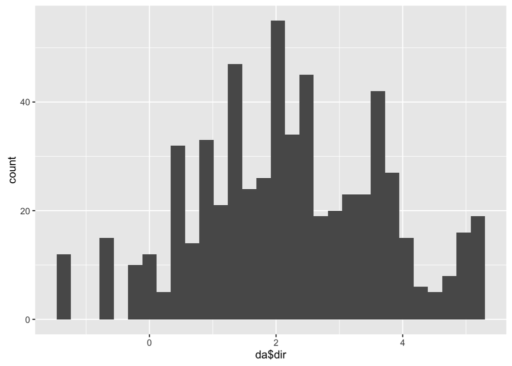

```r
da$dir<-log(0.75*da$dir_win+0.25*da$dir_nomi)
da$st1<-log(0.75*da$st1_win+0.25*da$st1_nomi)
da$st2<-log(0.75*da$st2_win+0.25*da$st2_nomi)
qplot(da$dir, geom="histogram",stat="count")
```

```r
resnew<-lm(logadjusted~studio+release_year+genre1+mpaa+rating+runt+per+sh+series+lgadbug+dir+st1+st2,na.omit(da))
#summary(resnew)
# R^2 53.69% AIC 93.0
#step3<-stepAIC(resnew,direction="backward")
res3<-lm(logadjusted ~ studio + release_year + genre1 + rating + runt + per + series + lgadbug,na.omit(da))
#summary(res3)
#R^2 55.97% AIC 86.20
resnew2<-lm(logbb~studio+release_year+genre1+mpaa+rating+runt+per+sh+series+dir+st1+st2,na.omit(da))
#summary(resnew2)
#52.2%
#step4<-stepAIC(resnew2,direction="backward")
res4<-lm(logbb ~ studio + release_year + genre1 +mpaa+ rating + per+ dir,na.omit(da))
#summary(res4)
#55.43%,AIC=118.8446
```

What if we ignore the normality assumption and stop making log transformation?

```r
resfull3<-lm(adjusted~studio+release_year+genre1+mpaa+rating+runt+per+sh+series+lgadbug+dir_win+dir_nomi+st1_win+st1_nomi+st2_win+st2_nomi,na.omit(da))
#step5<-stepAIC(resfull3,direction="backward")
res5<-lm(adjusted ~ studio + release_year + genre1 + rating + runt + per +
    series + dir_win + dir_nomi + st2_win + st2_nomi,na.omit(da))
#summary(res5)
resfull4<-lm(bb~studio+release_year+genre1+mpaa+rating+runt+per+sh+series+dir_win+dir_nomi+st1_win+st1_nomi+st2_win+st2_nomi,na.omit(da))
#step6<-stepAIC(resfull4,direction="backward")
res6<-lm(bb ~ studio + release_year + genre1 + mpaa + rating + runt,na.omit(da))
#summary(res6)
#42.08%,AIC=1182.888
```

### 5. conclusion

[output not shown]

```r
summary(res1)
```

```
##
## Call:
## lm(formula = logadjusted ~ studio + release_year + genre1 + rating +
##     runt + per + factor(sh) + series + lgdir_win + lgdir_nomi +
##     lgst2_nomi, data = na.omit(da))
##
## Residuals:
##     Min      1Q  Median      3Q     Max
## -0.5805 -0.1250  0.0000  0.1280  0.6989
##
## Coefficients: (1 not defined because of singularities)
##                   Estimate Std. Error t value Pr(>|t|)
## (Intercept)      78.807609  13.866947   5.683 6.40e-07 ***
## studioDW          0.106047   0.186275   0.569  0.57165
## studioFox        -0.228689   0.149795  -1.527  0.13302
## studioLGF         0.503957   0.329269   1.531  0.13206
## studioNL          0.215478   0.246956   0.873  0.38701
## studioP/DW       -0.285805   0.256828  -1.113  0.27100
## studioPar.       -0.483005   0.156566  -3.085  0.00328 **
## studioSony       -0.249020   0.179300  -1.389  0.17092
## studioTriS       -0.562267   0.376128  -1.495  0.14111
## studioUni.        0.026008   0.186774   0.139  0.88980
## studioWB         -0.268047   0.169062  -1.585  0.11903
## studioWB (NL)    -0.548880   0.381623  -1.438  0.15646
## studioWein.       0.060586   0.470752   0.129  0.89810
## release_year     -0.037577   0.007001  -5.368 1.97e-06 ***
## genre1Action     -0.019330   0.205299  -0.094  0.92535
## genre1Animation   0.160931   0.219496   0.733  0.46680
## genre1Comedy     -0.316868   0.231561  -1.368  0.17719
## genre1Crime      -0.823218   0.311543  -2.642  0.01091 *
## genre1Family     -0.050470   0.396147  -0.127  0.89912
## genre1Fantasy     0.145510   0.282635   0.515  0.60889
## genre1Historical -0.603870   0.421772  -1.432  0.15832
## genre1Horror            NA         NA      NA       NA
## genre1Music      -0.873416   0.411071  -2.125  0.03848 *
## genre1Musical    -0.295929   0.411844  -0.719  0.47570
## genre1Period     -0.403264   0.233942  -1.724  0.09081 .
## genre1Romantic   -0.511245   0.306717  -1.667  0.10168
## genre1Sci-Fi      0.287827   0.216651   1.329  0.18992
## genre1Thriller   -0.332400   0.318009  -1.045  0.30083
## genre1War        -1.181650   0.396029  -2.984  0.00436 **
## genre1Western    -0.602904   0.613617  -0.983  0.33047
## rating            0.206653   0.074080   2.790  0.00740 **
## runt              0.005496   0.002795   1.966  0.05475 .
## perns             0.337950   0.152963   2.209  0.03167 *
## perss             0.300875   0.152073   1.978  0.05329 .
## factor(sh)1       0.235252   0.247163   0.952  0.34568
## factor(sh)2       0.235755   0.236671   0.996  0.32389
## factor(sh)3       0.643771   0.315691   2.039  0.04662 *
## factor(sh)4      -0.214072   0.317097  -0.675  0.50266
## factor(sh)5       0.632015   0.291811   2.166  0.03502 *
## factor(sh)6       0.442117   0.386008   1.145  0.25741
## series            0.328619   0.100381   3.274  0.00191 **
## lgdir_win         0.190642   0.063394   3.007  0.00409 **
## lgdir_nomi       -0.152488   0.073479  -2.075  0.04303 *
## lgst2_nomi       -0.076978   0.047093  -1.635  0.10830
## ---
## Signif. codes:  0 '***' 0.001 '**' 0.01 '*' 0.05 '.' 0.1 ' ' 1
##
## Residual standard error: 0.3066 on 51 degrees of freedom
## Multiple R-squared:  0.7909, Adjusted R-squared:  0.6186
## F-statistic: 4.592 on 42 and 51 DF,  p-value: 2.256e-07
```

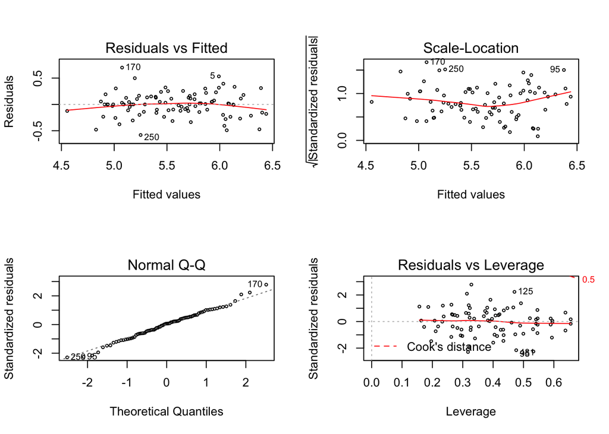

```r
layout(matrix(c(1,2,3,4),2,2))
plot(res1,cex=0.5)
```

```r
deviance(res1)
```

```
## [1] 4.793311
```

```r
mean(res1$residuals^2)
```

```
## [1] 0.05099267
```

```r
#mse,0.051 deviance 4.79
```

```r
#regression decision tree
#install.packages("rpart")
#install.packages("tree")
#install.packages("rpart.plot")
library(rpart)
library(rpart.plot)
library(tree)
```

```r
#rpart package
frmla<-bb~studio+release_year+genre1+mpaa+rating+runt+per+sh+series+rn+to_rating+dir_win+dir_nomi+st1_win+st1_nomi+st2_win+st2_nomi
#frm2<-bb~studio+release_year+genre1+mpaa+rating+runt+per+sh+series+rn+to_rating+dir_win+dir_nomi+st1_win+st1_nomi+st2_win+st2_nomi
fit<-rpart(frmla,method="anova",data=da,minbucket=10)
printcp(fit)
```

```
##
## Regression tree:
## rpart(formula = frmla, data = da, method = "anova", minbucket = 10)
##
## Variables actually used in tree construction:
## [1] genre1       release_year studio
##
## Root node error: 11264/547 = 20.593
##
## n=547 (86 observations deleted due to missingness)
##
##         CP nsplit rel error  xerror    xstd
## 1 0.160250      0   1.00000 1.00945 0.29718
## 2 0.150171      1   0.83975 1.12469 0.30178
## 3 0.037129      2   0.68958 0.99951 0.26371
## 4 0.024909      3   0.65245 0.92108 0.25162
## 5 0.023128      4   0.62754 0.91881 0.24286
## 6 0.010000      5   0.60441 0.88723 0.23960
```

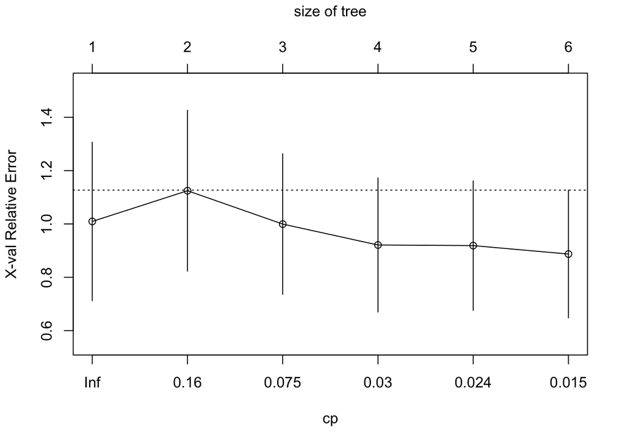

```r
par(mfrow=c(1,1))
plotcp(fit) # visualize cross-validation results
```

```r
summary(fit) # detailed summary of splits
```

```
## Call:
## rpart(formula = frmla, data = da, method = "anova", minbucket = 10)
##   n=547 (86 observations deleted due to missingness)
##
##           CP nsplit rel error    xerror      xstd
## 1 0.16024981      0 1.0000000 1.0094459 0.2971760
## 2 0.15017060      1 0.8397502 1.1246873 0.3017805
## 3 0.03712850      2 0.6895796 0.9995054 0.2637132
## 4 0.02490944      3 0.6524511 0.9210849 0.2516180
## 5 0.02312823      4 0.6275416 0.9188135 0.2428644
## 6 0.01000000      5 0.6044134 0.8872268 0.2396046
##
## Variable importance
## release_year       studio       genre1     st1_nomi      st1_win
##           41           39           10            4            3
##         runt         mpaa
##            2            1
##
## Node number 1: 547 observations,    complexity param=0.1602498
##   mean=2.99245, MSE=20.59257
##   left son=2 (531 obs) right son=3 (16 obs)
##   Primary splits:
##       release_year < 1987.5 to the right, improve=0.16024980, (0 missing)
##       studio       splits as  LLL-LLLR-LRLL-LLLRLLLL-LLLLRLLL-RLLLL, improve=0.14646640, (0 missing)
##       genre1       splits as  LLLLR-R-RRLRRRLLLRRLLLLL, improve=0.07900972, (0 missing)
##       rating       < 8.65   to the left,  improve=0.03950928, (4 missing)
##       dir_win      < 39.5   to the left,  improve=0.03034776, (19 missing)
##   Surrogate splits:
##       studio splits as  LLL-RLLL-LLLL-LLLLLLLL-LLLLLLLL-RLLLL, agree=0.974, adj=0.125, (0 split)
##
## Node number 2: 531 observations,    complexity param=0.1501706
##   mean=2.677119, MSE=12.04427
##   left son=4 (521 obs) right son=5 (10 obs)
##   Primary splits:
##       studio       splits as  LLL--LLR-LRLL-LLLRLLLL-LLLLRLLL--LLLL, improve=0.26448920, (0 missing)
##       genre1       splits as  LLLLR-L-RLLRRRLRLRRLLLLL, improve=0.11527510, (0 missing)
##       release_year < 1994.5 to the right, improve=0.05454308, (0 missing)
##       rn           < 129.5  to the right, improve=0.02421584, (263 missing)
##       st2_nomi     < 5.5    to the right, improve=0.01803466, (47 missing)
##
```

[output cut: 42 more lines]

```
##       studio   splits as  -RL---L--R----LRL-L-L----L--LLL---L--, agree=0.848, adj=0.462, (0 split)
##       runt     < 95     to the right, agree=0.826, adj=0.385, (0 split)
##       mpaa     splits as  R-LLL-, agree=0.783, adj=0.231, (0 split)
##
## Node number 16: 400 observations
##   mean=1.83035, MSE=1.800879
##
## Node number 17: 75 observations
##   mean=3.861333, MSE=11.06381
##
## Node number 18: 33 observations
##   mean=3.758788, MSE=4.921326
##
## Node number 19: 13 observations
##   mean=9.243846, MSE=13.9099
```

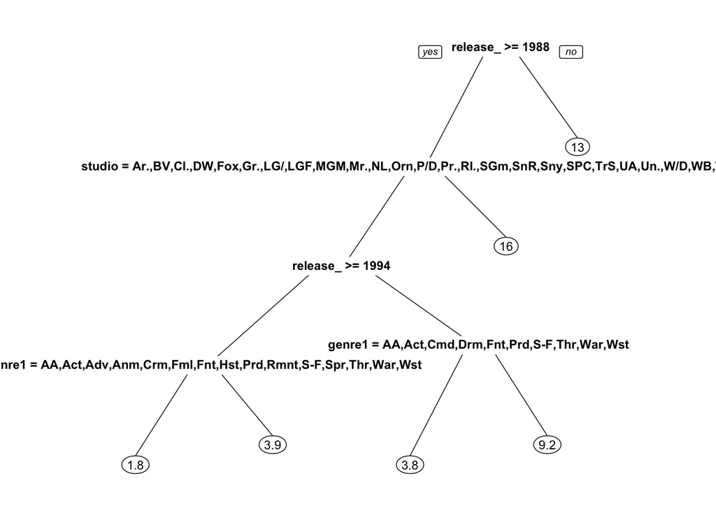

```r
rpart.plot(fit)
```

```r
predict_tree<-predict(fit,da)
tree_rmse<-mean((predict_tree-da$bb)^2,na.rm=TRUE)
#tree mse: 12.4464
# tree package
frmla_tree<-bb~mpaa+rating+runt+per+sh+series+rn+to_rating+dir_win+dir_nomi+st1_win+st1_nomi+st2_win+st2_nomi+genre1
tree<-tree(frmla_tree,data=da)
summary(tree)
```

```
##
## Regression tree:
## tree(formula = frmla_tree, data = da)
## Variables actually used in tree construction:
## [1] "genre1"   "rating"   "st1_nomi"
## Number of terminal nodes:  7
## Residual mean deviance:  16.01 = 3762 / 235
## Distribution of residuals:
##     Min.  1st Qu.   Median     Mean  3rd Qu.     Max.
## -19.4600  -1.1820  -0.5025   0.0000   0.6075  33.2300
```

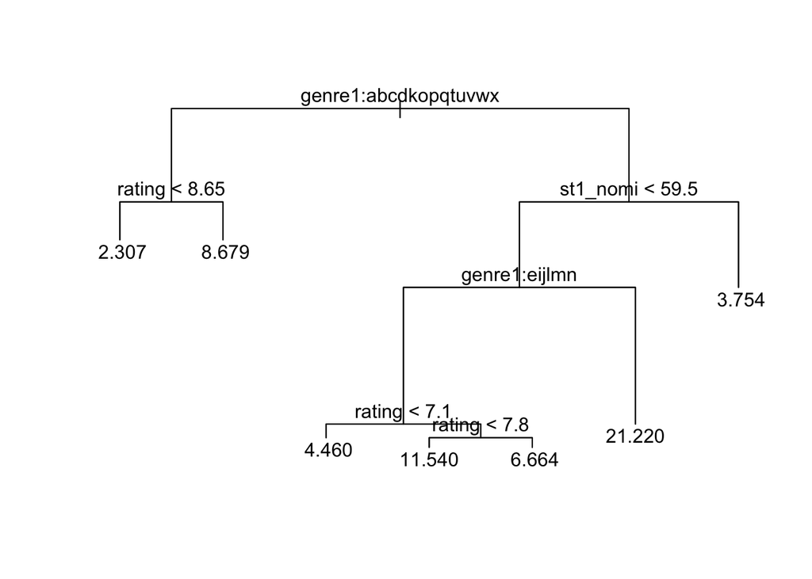

```r
plot(tree);text(tree)
```

```r
#deviance:(mean square error): 16.01
```

Release_year,studio,genre,awards of star 1, runtime and mpaa are relatively important when predicting the outcome. Distinctive genres: AA, Action,Adventure,Animation,Crime,Fantasy,Si-Fi,Sports,Thriller, West, War.